# Power Analysis: Introduction

## Typical reported effect sizes II

### Bosco et al. (2015), correlation metric

- 147,328 correlations from Journal of Applied Psychology and Personnel Psychology
- median effect: *r* = .16, mean effect *r* = .22 (SD = .20)

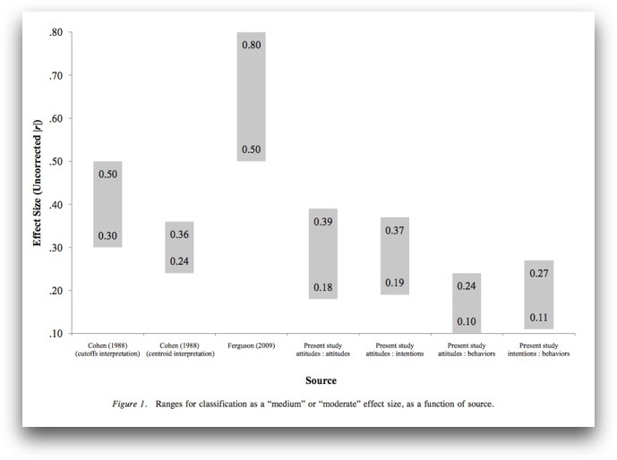

Bosco et al. (2015). Correlational effect size benchmarks. http://doi.org/10.1037/a0038047

## Typical reported effect sizes III

### Hill et al. (2008), Hedge’s *g*

- How does the effect of an intervention compare to a typical year of growth in school?

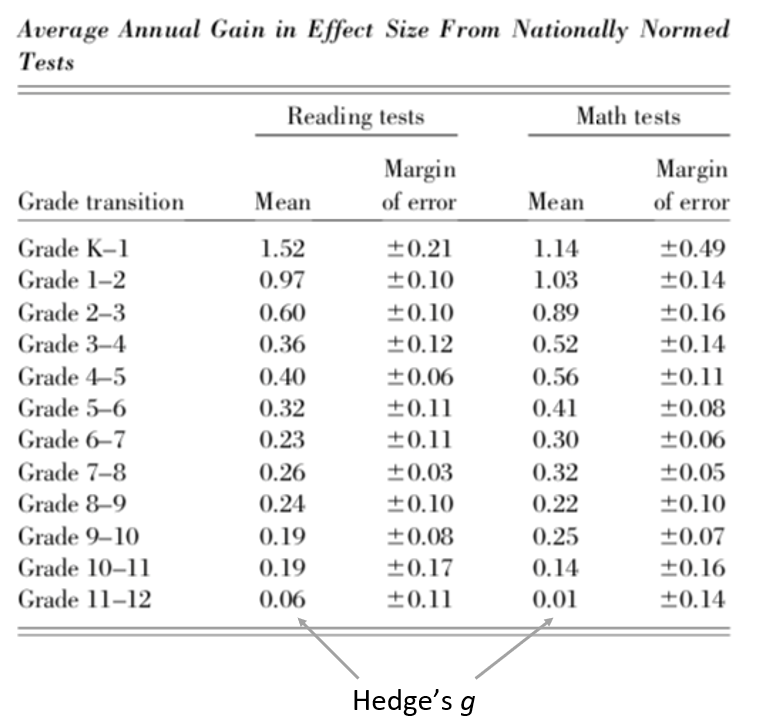

Hill et al. (2008). Empirical Benchmarks for Interpreting Effect Sizes in Research. doi:10.1111/j.1750-8606.2008.00061.x

## Typical reported effect sizes IV

### Funder & Ozer (2019), correlation metric

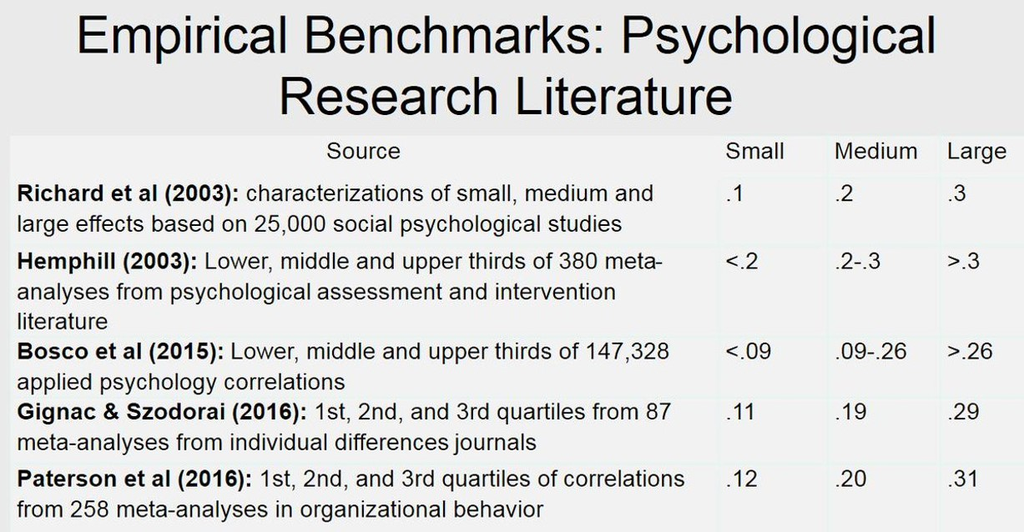

Funder, D. C., & Ozer, D. J. (2019). Evaluating Effect Size in Psychological Research: Sense and Nonsense. Advances in Methods and Practices in Psychological Science, 2, 156–168. doi:10.1177/2515245919847202

## Typical reported effect sizes V

### Aguinis, Beaty, Boik, & Pierce (2005), $f^2$

Effect size of interaction from dichotomous moderator and continuous predictor

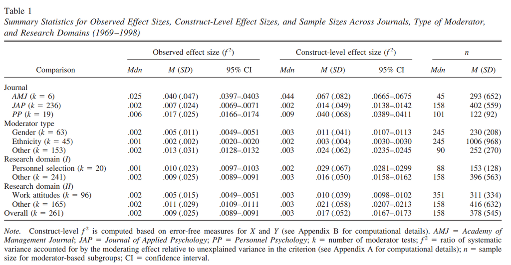

Aguinis et al. (2005). Effect size and power in assessing moderating effects of categorical variables using multiple regression: a 30-year review. Journal of Applied Psychology, 90(1), 94.

## Other benchmarks I

**Average placebo effect?**

*d* = 0.24 [0.17; 0.31]!

Hróbjartsson, A., & Gøtzsche, P. C. (2004). Is the placebo powerless? Update of a systematic review with 52 new randomized trials comparing placebo with no treatment. Journal of internal medicine, 256(2), 91-100.

## Other benchmarks II (ES: *d*)

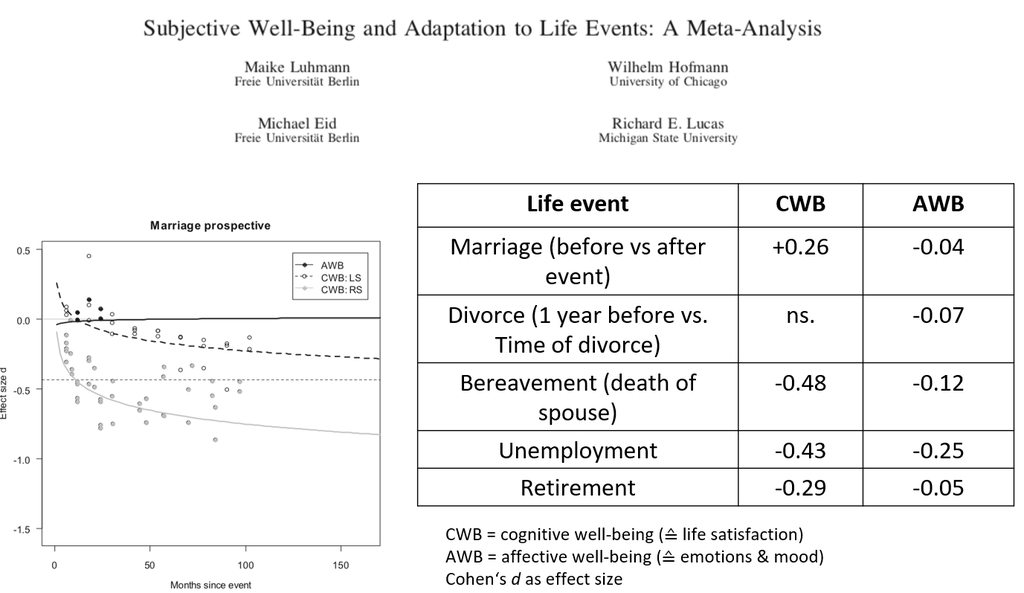

Luhmann, M., Hofmann, W., Eid, M., & Lucas, R. E. (2012). Subjective well-being and adaptation to life events: a meta-analysis. Journal of Personality and Social Psychology, 102(3), 592–615. http://doi.org/10.1037/a0025948

# The trustworthiness of effect sizes in the literature

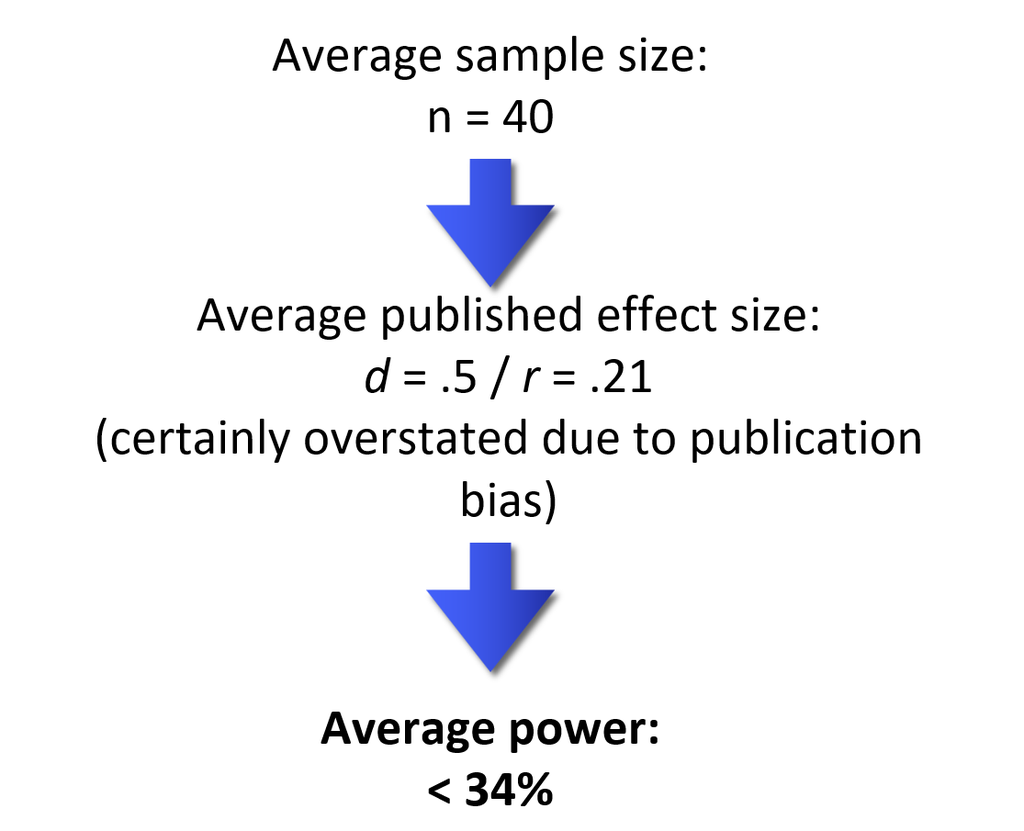

Bakker, M., van Dijk, A., & Wicherts, J. M. (2012). The Rules of the Game Called Psychological Science. Perspectives on Psychological Science, 7(6), 543–554.

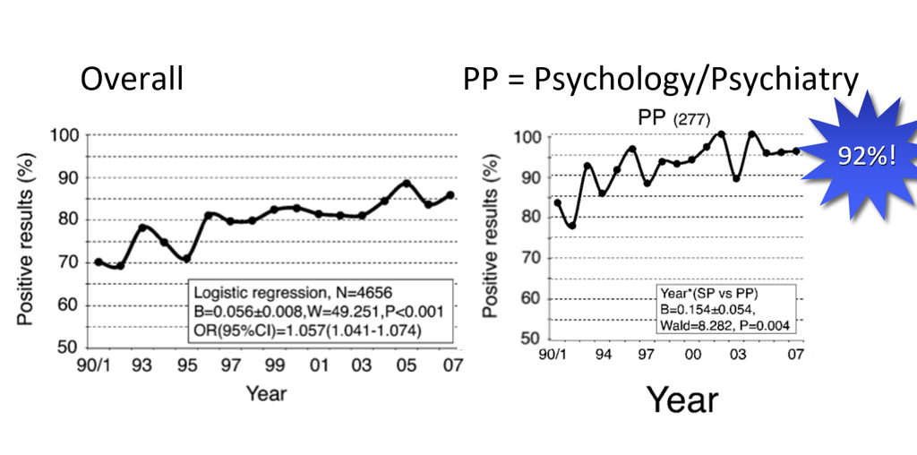

Fanelli, D. (2011). Negative results are disappearing from most disciplines and countries. Scientometrics, 90(3), 891–904. doi:10.1007/s11192-011-0494-7

## Can we base our power analyses on published effect sizes?

**No.**

- See RP:P: 83% of all effect sizes are smaller than the original:  
  Mean original: *r* = .40 ➙ Mean replication: *r* = .20
- See also Franco et al. (2015):  
  Reported ES 2x larger than unreported ES

## Can we base our power analyses on published effect sizes?

• See Schäfer & Schwarz (2019), ES: r:

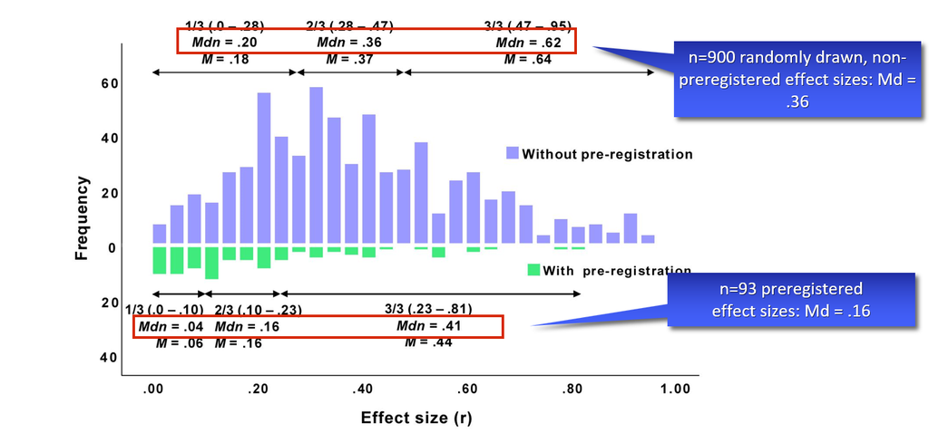

Schäfer, T., & Schwarz, M. A. (2019). The meaningfulness of effect sizes in psychological research: Differences between sub-disciplines and the impact of potential biases.Frontiers in Psychology,10, 813.

## Can we base our power analyses on published effect sizes?

- Suggestion 1: Divide reported effect by 2, compute power analysis.
- Suggestion 2: Safeguard power (Perugini, 2014): Incorporate uncertainty in original study’s ES estimate. Aim lower end of 60%-CI.

## Safeguard power

### Perugini et al., 2014

- Incorporate uncertainty in original study’s ES estimate
- Aim for lower end of 60%-CI
- Example:
  - Original study finds *d* = 0.5 (*n* = 30 in each group)
  - 60% CI = [0.28; 0.72]
  - Naive 80% power analysis: *n* = 64
  - Safeguard 80% power analysis: *n* = 202
- Rewards precise estimates in original study

```r
library(MBESS)
ci.smd(smd=0.5, n.1=30, n.2=30, conf.level=0.60)
```

# End

## Contact

- [@nicebread@scicomm.xyz](https://scicomm.xyz/@nicebread)
- ed.uml.ysp@tdorbneohcs.xilef
- https://www.nicebread.de
- https://github.com/nicebread